# Fit_Test_Proportion_Studies

Lan Tao

2023-10-26

## Greedy Algorithm

```r
# Greedy m=70, pa=0.5, p1=0.03, p2=0.01, pr=2
data <- num_greedy_05_m70_pr2_11$prop_s

exp_s<-mean(data[500:1000], na.rm = TRUE)
var_s<-var(data[500:1000],na.rm = TRUE)

alpha = exp_s*(exp_s*(1-exp_s)/var_s-1)
beta  = (1-exp_s)*(exp_s*(1-exp_s)/var_s-1)

alpha
```

```
## [1] 5.031785
```

```r
beta
```

```
## [1] 1.398451
```

```r
### Kolmogorov-Smirnov Tests
x_1 <- data
x_2 <- rbeta(n = 501, shape1 = alpha, shape2 = beta)

ks.test(x_1, "pbeta", alpha, beta)
```

```
##
##  Asymptotic one-sample Kolmogorov-Smirnov test
##
## data:  x_1
## D = 0.082985, p-value = 2.116e-06
## alternative hypothesis: two-sided
```

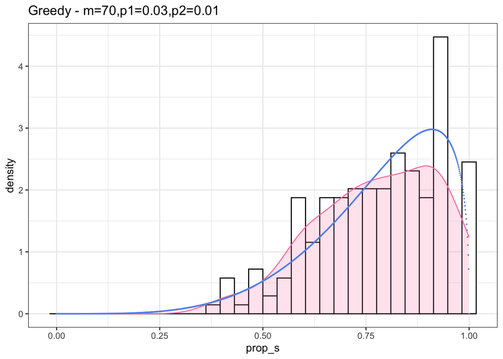

```r
# ks.test(x_1, x_2)

# Visual inspection
x <- seq(0,1,by=0.001)
fitted_val <- dbeta(x,shape1=alpha,shape2=beta)

fitted_data<-data.frame(x,fitted_val)

ggplot(num_greedy_05_m70_pr2_11[800:1000,], aes(x=prop_s)) +
  geom_histogram(aes(y=..density..), colour="black", fill="white")+
  geom_density(alpha=.2, colour="palevioletred1",fill="palevioletred1")+
  geom_point(data = fitted_data, aes(x = x, y = fitted_val), colour = "cornflowerblue",size=0.1,show.legend = TRUE)+
  labs(title = "Greedy - m=70,p1=0.03,p2=0.01")+
  theme_bw()
```

### Greedy - group 12 (m=70, pa=0.5, p1=0.05, p2=0.01, pr=2)

```r
# Greedy m=70, pa=0.5, p1=0.05, p2=0.01, pr=2
data <- num_greedy_05_m70_pr2_12$prop_s

exp_s<-mean(data[500:1000], na.rm = TRUE)
var_s<-var(data[500:1000],na.rm = TRUE)

alpha = exp_s*(exp_s*(1-exp_s)/var_s-1)
beta  = (1-exp_s)*(exp_s*(1-exp_s)/var_s-1)

alpha
```

```
## [1] 3.801253
```

```r
beta
```

```
## [1] 1.320809
```

```r
### Kolmogorov-Smirnov Tests
x_1 <- data
x_2 <- rbeta(n = 501, shape1 = alpha, shape2 = beta)

ks.test(x_1, "pbeta", alpha, beta)
```

```
##
##  Asymptotic one-sample Kolmogorov-Smirnov test
##
## data:  x_1
## D = 0.12212, p-value = 2.29e-13
## alternative hypothesis: two-sided
```

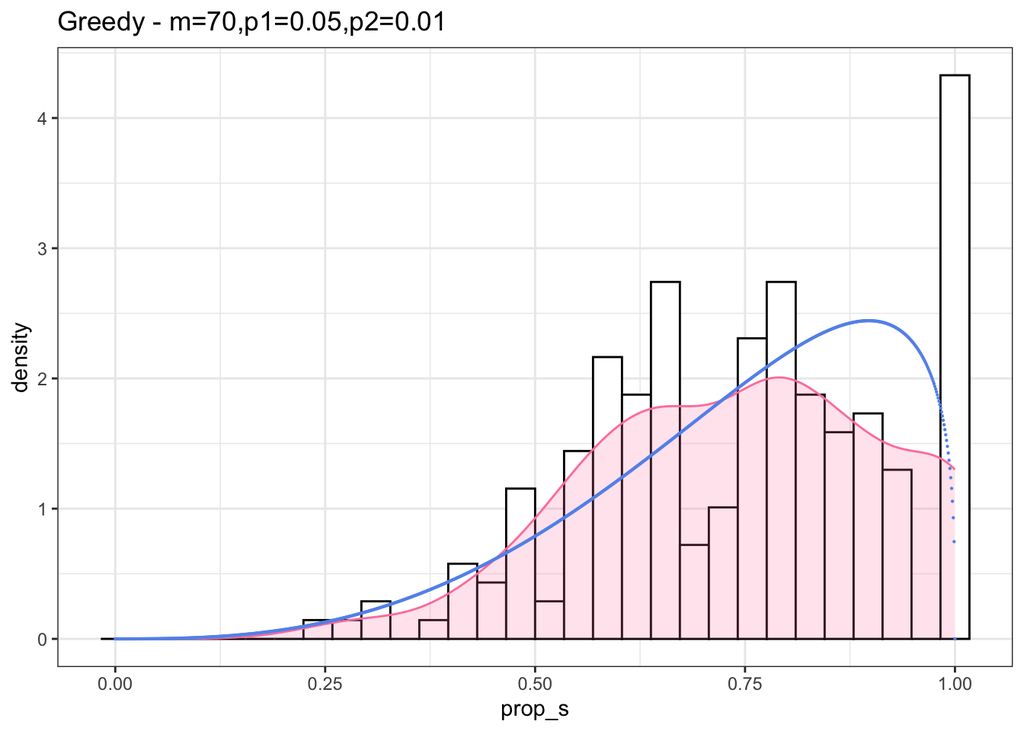

```r
# ks.test(x_1, x_2)

# Visual inspection
x <- seq(0,1,by=0.001)
fitted_val <- dbeta(x,shape1=alpha,shape2=beta)

fitted_data<-data.frame(x,fitted_val)

ggplot(num_greedy_05_m70_pr2_12[800:1000,], aes(x=prop_s)) +
  geom_histogram(aes(y=..density..), colour="black", fill="white")+
  geom_density(alpha=.2, colour="palevioletred1",fill="palevioletred1")+
  geom_point(data = fitted_data, aes(x = x, y = fitted_val), colour = "cornflowerblue",size=0.1,show.legend = TRUE)+
  labs(title = "Greedy - m=70,p1=0.05,p2=0.01")+
  theme_bw()
```

### Greedy - group 13 (m=70, pa=0.5, p1=0.1, p2=0.01, pr=2)

```r
# Greedy m=70, pa=0.5, p1=0.1, p2=0.01, pr=2
data <- num_greedy_05_m70_pr2_13$prop_s

exp_s<-mean(data[500:1000], na.rm = TRUE)
var_s<-var(data[500:1000],na.rm = TRUE)

alpha = exp_s*(exp_s*(1-exp_s)/var_s-1)
beta  = (1-exp_s)*(exp_s*(1-exp_s)/var_s-1)

alpha
```

```
## [1] NaN
```

```r
beta
```

```
## [1] NaN
```

```r
### Kolmogorov-Smirnov Tests
x_1 <- data
x_2 <- rbeta(n = 501, shape1 = alpha, shape2 = beta)
ks.test(x_1, "pbeta", alpha, beta)
```

```
##
##  Asymptotic one-sample Kolmogorov-Smirnov test
##
## data:  x_1
## D = NaN, p-value = NA
## alternative hypothesis: two-sided
```

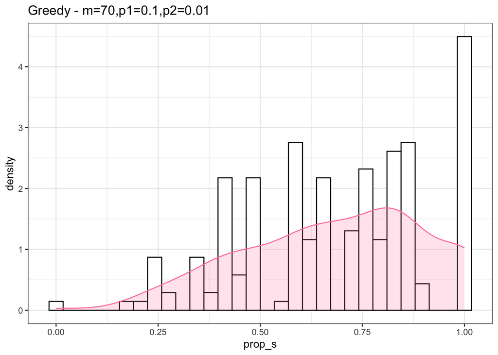

```r
# Visual inspection
x <- seq(0,1,by=0.001)
fitted_val <- dbeta(x,shape1=alpha,shape2=beta)

fitted_data<-data.frame(x,fitted_val)

ggplot(num_greedy_05_m70_pr2_13[800:1000,], aes(x=prop_s)) +
  geom_histogram(aes(y=..density..), colour="black", fill="white")+
  geom_density(alpha=.2, colour="palevioletred1",fill="palevioletred1")+
  geom_point(data = fitted_data, aes(x = x, y = fitted_val), colour = "cornflowerblue",size=0.1,show.legend = TRUE)+
  labs(title = "Greedy - m=70,p1=0.1,p2=0.01")+
  theme_bw()
```

### Greedy - group 14 (m=70, pa=0.5, p1=0.8, p2=0.01, pr=2)

```r
# Greedy m=70, pa=0.5, p1=0.8, p2=0.01, pr=2
data <- num_greedy_05_m70_pr2_14$prop_s

exp_s<-mean(data[500:1000], na.rm = TRUE)
var_s<-var(data[500:1000],na.rm = TRUE)

alpha = exp_s*(exp_s*(1-exp_s)/var_s-1)
beta  = (1-exp_s)*(exp_s*(1-exp_s)/var_s-1)

alpha
```

```
## [1] NaN
```

```r
beta
```

```
## [1] NaN
```

```r
### Kolmogorov-Smirnov Tests
x_1 <- data
x_2 <- rbeta(n = 501, shape1 = alpha, shape2 = beta)
ks.test(x_1, "pbeta", alpha, beta)
```

```
##
##  Asymptotic one-sample Kolmogorov-Smirnov test
##
## data:  x_1
## D = NaN, p-value = NA
## alternative hypothesis: two-sided
```

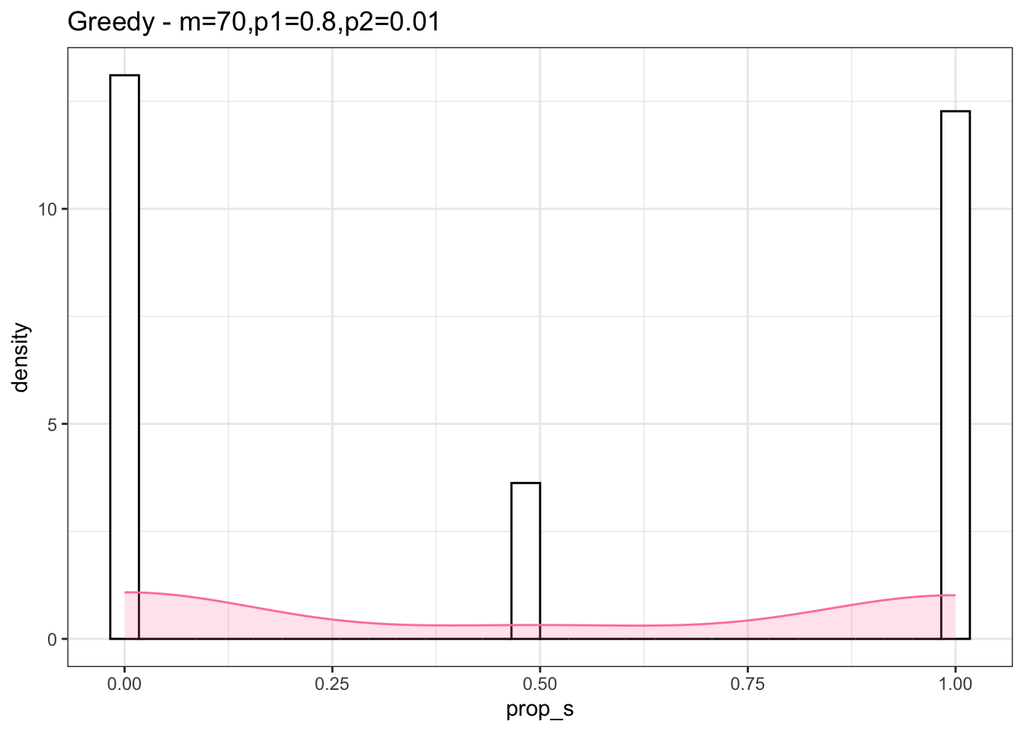

```r
# ks.test(x_1, x_2)

# Visual inspection
x <- seq(0,1,by=0.001)
fitted_val <- dbeta(x,shape1=alpha,shape2=beta)

fitted_data<-data.frame(x,fitted_val)

ggplot(num_greedy_05_m70_pr2_14[800:1000,], aes(x=prop_s)) +
  geom_histogram(aes(y=..density..), colour="black", fill="white")+
  geom_density(alpha=.2, colour="palevioletred1",fill="palevioletred1")+
  geom_point(data = fitted_data, aes(x = x, y = fitted_val), colour = "cornflowerblue",size=0.1,show.legend = TRUE)+
  labs(title = "Greedy - m=70,p1=0.8,p2=0.01")+
  theme_bw()
```

### Greedy - group 21 (m=100, pa=0.5, p1=0.03, p2=0.01, pr=2)

```r
# Greedy m=100, pa=0.5, p1=0.03, p2=0.01, pr=2
data <- num_greedy_05_m100_pr2_11$prop_s

exp_s<-mean(data[500:1000], na.rm = TRUE)
var_s<-var(data[500:1000],na.rm = TRUE)

alpha = exp_s*(exp_s*(1-exp_s)/var_s-1)
beta  = (1-exp_s)*(exp_s*(1-exp_s)/var_s-1)

alpha
```

```
## [1] 4.841687
```

```r
beta
```

```
## [1] 1.53856
```

```r
### Kolmogorov-Smirnov Tests
x_1 <- data
x_2 <- rbeta(n = 501, shape1 = alpha, shape2 = beta)

ks.test(x_1, "pbeta", alpha, beta)
```

```
##
##  Asymptotic one-sample Kolmogorov-Smirnov test
##
## data:  x_1
## D = 0.081081, p-value = 3.949e-06
## alternative hypothesis: two-sided
```

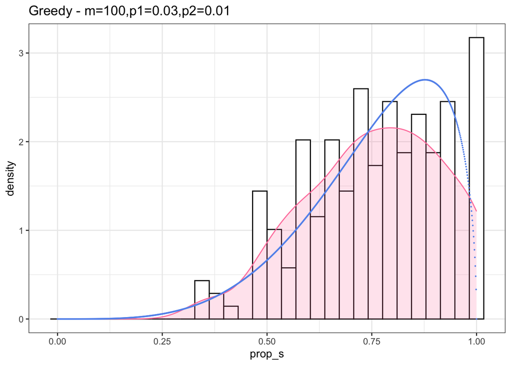

```r
# ks.test(x_1, x_2)

# Visual inspection
x <- seq(0,1,by=0.001)
fitted_val <- dbeta(x,shape1=alpha,shape2=beta)

fitted_data<-data.frame(x,fitted_val)

ggplot(num_greedy_05_m100_pr2_11[800:1000,], aes(x=prop_s)) +
  geom_histogram(aes(y=..density..), colour="black", fill="white")+
  geom_density(alpha=.2, colour="palevioletred1",fill="palevioletred1")+
  geom_point(data = fitted_data, aes(x = x, y = fitted_val), colour = "cornflowerblue",size=0.1,show.legend = TRUE)+
  labs(title = "Greedy - m=100,p1=0.03,p2=0.01")+
  theme_bw()
```

### Greedy - group 22 (m=100, pa=0.5, p1=0.05, p2=0.01, pr=2)

```r
# Greedy m=100, pa=0.5, p1=0.05, p2=0.01, pr=2
data <- num_greedy_05_m100_pr2_12$prop_s

exp_s<-mean(data[500:1000], na.rm = TRUE)
var_s<-var(data[500:1000],na.rm = TRUE)

alpha = exp_s*(exp_s*(1-exp_s)/var_s-1)
beta  = (1-exp_s)*(exp_s*(1-exp_s)/var_s-1)

alpha
```

```
## [1] 3.512862
```

```r
beta
```

```
## [1] 1.249651
```

```r
### Kolmogorov-Smirnov Tests
x_1 <- data
x_2 <- rbeta(n = 501, shape1 = alpha, shape2 = beta)

ks.test(x_1, "pbeta", alpha, beta)
```

```
##
##  Asymptotic one-sample Kolmogorov-Smirnov test
##
## data:  x_1
## D = 0.1021, p-value = 1.8e-09
## alternative hypothesis: two-sided
```

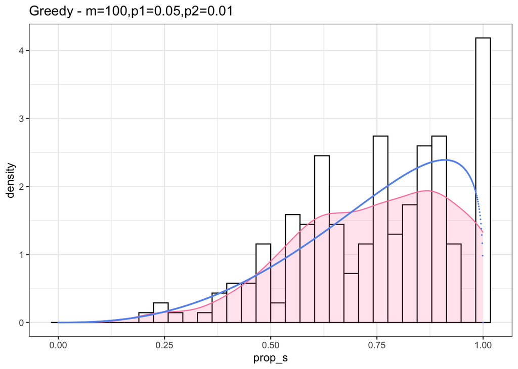

```r
# ks.test(x_1, x_2)

# Visual inspection
x <- seq(0,1,by=0.001)
fitted_val <- dbeta(x,shape1=alpha,shape2=beta)

fitted_data<-data.frame(x,fitted_val)

ggplot(num_greedy_05_m100_pr2_12[800:1000,], aes(x=prop_s)) +
  geom_histogram(aes(y=..density..), colour="black", fill="white")+
  geom_density(alpha=.2, colour="palevioletred1",fill="palevioletred1")+
  geom_point(data = fitted_data, aes(x = x, y = fitted_val), colour = "cornflowerblue",size=0.1,show.legend = TRUE)+
  labs(title = "Greedy - m=100,p1=0.05,p2=0.01")+
  theme_bw()
```

### Greedy - group 23 (m=100, pa=0.5, p1=0.1, p2=0.01, pr=2)

```r
# Greedy m=100, pa=0.5, p1=0.1, p2=0.01, pr=2
data <- num_greedy_05_m100_pr2_13$prop_s

exp_s<-mean(data[500:1000], na.rm = TRUE)
var_s<-var(data[500:1000],na.rm = TRUE)

alpha = exp_s*(exp_s*(1-exp_s)/var_s-1)
beta  = (1-exp_s)*(exp_s*(1-exp_s)/var_s-1)

alpha
```

```
## [1] 2.57882
```

```r
beta
```

```
## [1] 1.275602
```

```r
### Kolmogorov-Smirnov Tests
x_1 <- data
x_2 <- rbeta(n = 501, shape1 = alpha, shape2 = beta)

ks.test(x_1, "pbeta", alpha, beta)
```

```
##
##  Asymptotic one-sample Kolmogorov-Smirnov test
##
## data:  x_1
## D = 0.14314, p-value < 2.2e-16
## alternative hypothesis: two-sided
```

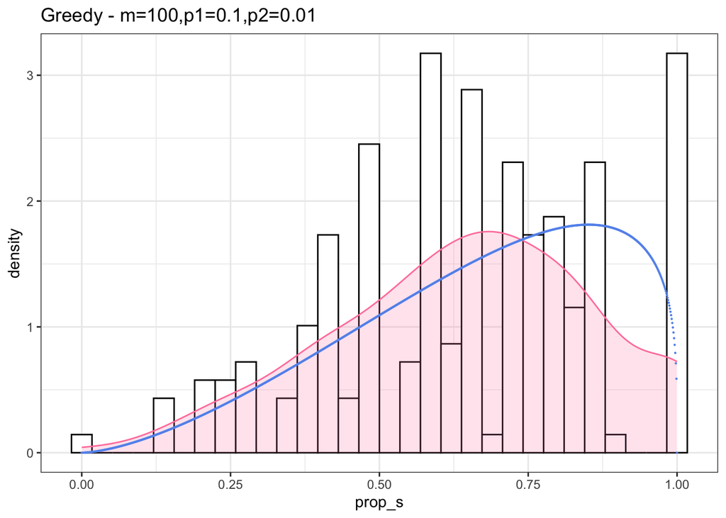

```r
# ks.test(x_1, x_2)

# Visual inspection
x <- seq(0,1,by=0.001)
fitted_val <- dbeta(x,shape1=alpha,shape2=beta)

fitted_data<-data.frame(x,fitted_val)

ggplot(num_greedy_05_m100_pr2_13[800:1000,], aes(x=prop_s)) +
  geom_histogram(aes(y=..density..), colour="black", fill="white")+
  geom_density(alpha=.2, colour="palevioletred1",fill="palevioletred1")+
  geom_point(data = fitted_data, aes(x = x, y = fitted_val), colour = "cornflowerblue",size=0.1,show.legend = TRUE)+
  labs(title = "Greedy - m=100,p1=0.1,p2=0.01")+
  theme_bw()
```

### Greedy - group 24 (m=100, pa=0.5, p1=0.8, p2=0.01, pr=2)

```r
# Greedy m=100, pa=0.5, p1=0.8, p2=0.01, pr=2
data <- num_greedy_05_m100_pr2_14$prop_s

exp_s<-mean(data[500:1000], na.rm = TRUE)
var_s<-var(data[500:1000],na.rm = TRUE)

alpha = exp_s*(exp_s*(1-exp_s)/var_s-1)
beta  = (1-exp_s)*(exp_s*(1-exp_s)/var_s-1)

alpha
```

```
## [1] NaN
```

```r
beta
```

```
## [1] NaN
```

```r
### Kolmogorov-Smirnov Tests
x_1 <- data
x_2 <- rbeta(n = 501, shape1 = alpha, shape2 = beta)
ks.test(x_1, "pbeta", alpha, beta)
```

```
##
##  Asymptotic one-sample Kolmogorov-Smirnov test
##
## data:  x_1
## D = NaN, p-value = NA
## alternative hypothesis: two-sided
```

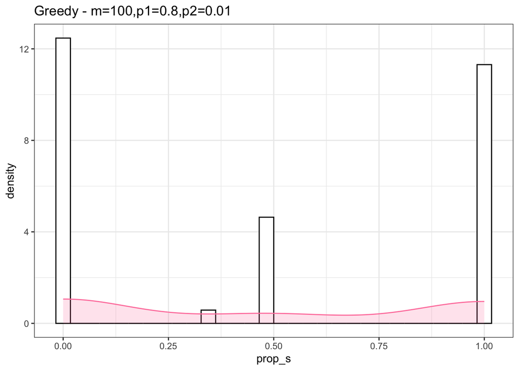

```r
# ks.test(x_1, x_2)

# Visual inspection
x <- seq(0,1,by=0.001)
fitted_val <- dbeta(x,shape1=alpha,shape2=beta)

fitted_data<-data.frame(x,fitted_val)

ggplot(num_greedy_05_m100_pr2_14[800:1000,], aes(x=prop_s)) +
  geom_histogram(aes(y=..density..), colour="black", fill="white")+
  geom_density(alpha=.2, colour="palevioletred1",fill="palevioletred1")+
  geom_point(data = fitted_data, aes(x = x, y = fitted_val), colour = "cornflowerblue",size=0.1,show.legend = TRUE)+
  labs(title = "Greedy - m=100,p1=0.8,p2=0.01")+
  theme_bw()
```

### Patient - group 11 (m=70, pa=0.5, p1=0.03, p2=0.01, pr=2)

```r
# Patient m=70, pa=0.5, p1=0.03, p2=0.01, pr=2
data <- num_patient_05_m70_pr2_11$prop_s

exp_s<-mean(data[500:1000], na.rm = TRUE)
var_s<-var(data[500:1000],na.rm = TRUE)

alpha = exp_s*(exp_s*(1-exp_s)/var_s-1)
beta  = (1-exp_s)*(exp_s*(1-exp_s)/var_s-1)

alpha
```

```
## [1] 9.336118
```

```r
beta
```

```
## [1] 1.808847
```

```r
### Kolmogorov-Smirnov Tests
x_1 <- data
x_2 <- rbeta(n = 501, shape1 = alpha, shape2 = beta)

ks.test(x_1, "pbeta", alpha, beta)
```

```
##
##  Asymptotic one-sample Kolmogorov-Smirnov test
##
## data:  x_1
## D = 0.066511, p-value = 0.0002901
## alternative hypothesis: two-sided
```

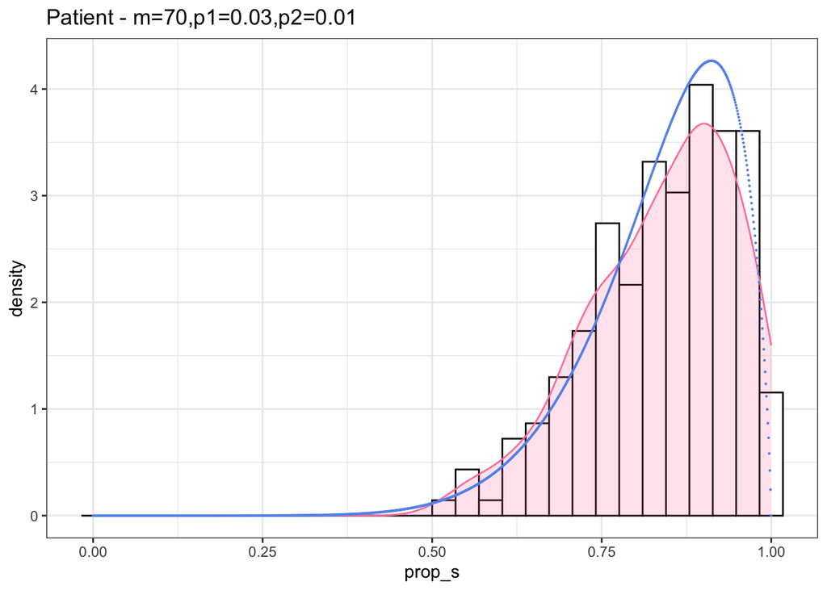

```r
# ks.test(x_1, x_2)

# Visual inspection
x <- seq(0,1,by=0.001)
fitted_val <- dbeta(x,shape1=alpha,shape2=beta)

fitted_data<-data.frame(x,fitted_val)

ggplot(num_patient_05_m70_pr2_11[800:1000,], aes(x=prop_s)) +
  geom_histogram(aes(y=..density..), colour="black", fill="white")+
  geom_density(alpha=.2, colour="palevioletred1",fill="palevioletred1")+
  geom_point(data = fitted_data, aes(x = x, y = fitted_val), colour = "cornflowerblue",size=0.1,show.legend = TRUE)+
  labs(title = "Patient - m=70,p1=0.03,p2=0.01")+
  theme_bw()
```

### Patient - group 12 (m=70, pa=0.5, p1=0.05, p2=0.01, pr=2)

```r
# Patient m=70, pa=0.5, p1=0.05, p2=0.01, pr=2
data <- num_patient_05_m70_pr2_12$prop_s

exp_s<-mean(data[500:1000], na.rm = TRUE)
var_s<-var(data[500:1000],na.rm = TRUE)

alpha = exp_s*(exp_s*(1-exp_s)/var_s-1)
beta  = (1-exp_s)*(exp_s*(1-exp_s)/var_s-1)

alpha
```

```
## [1] 7.101472
```

```r
beta
```

```
## [1] 1.509657
```

```r
### Kolmogorov-Smirnov Tests
x_1 <- data
x_2 <- rbeta(n = 501, shape1 = alpha, shape2 = beta)

ks.test(x_1, "pbeta", alpha, beta)
```

```
##
##  Asymptotic one-sample Kolmogorov-Smirnov test
##
## data:  x_1
## D = 0.052135, p-value = 0.008761
## alternative hypothesis: two-sided
```

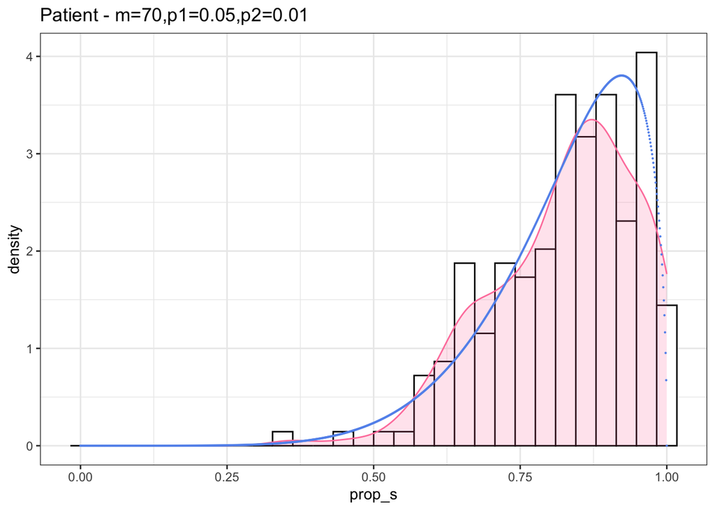

```r
# ks.test(x_1, x_2)

# Visual inspection
x <- seq(0,1,by=0.001)
fitted_val <- dbeta(x,shape1=alpha,shape2=beta)

fitted_data<-data.frame(x,fitted_val)

ggplot(num_patient_05_m70_pr2_12[800:1000,], aes(x=prop_s)) +
  geom_histogram(aes(y=..density..), colour="black", fill="white")+
  geom_density(alpha=.2, colour="palevioletred1",fill="palevioletred1")+
  geom_point(data = fitted_data, aes(x = x, y = fitted_val), colour = "cornflowerblue",size=0.1,show.legend = TRUE)+
  labs(title = "Patient - m=70,p1=0.05,p2=0.01")+
  theme_bw()
```

### Patient - group 13 (m=70, pa=0.5, p1=0.1, p2=0.01, pr=2)

```r
# Patient m=70, pa=0.5, p1=0.1, p2=0.01, pr=2
data <- num_patient_05_m70_pr2_13$prop_s

exp_s<-mean(data[500:1000], na.rm = TRUE)
var_s<-var(data[500:1000],na.rm = TRUE)

alpha = exp_s*(exp_s*(1-exp_s)/var_s-1)
beta  = (1-exp_s)*(exp_s*(1-exp_s)/var_s-1)

alpha
```

```
## [1] 6.311466
```

```r
beta
```

```
## [1] 1.522246
```

```r
### Kolmogorov-Smirnov Tests
x_1 <- data
x_2 <- rbeta(n = 501, shape1 = alpha, shape2 = beta)

ks.test(x_1, "pbeta", alpha, beta)
```

```
##
##  Asymptotic one-sample Kolmogorov-Smirnov test
##
## data:  x_1
## D = 0.042042, p-value = 0.05852
## alternative hypothesis: two-sided
```

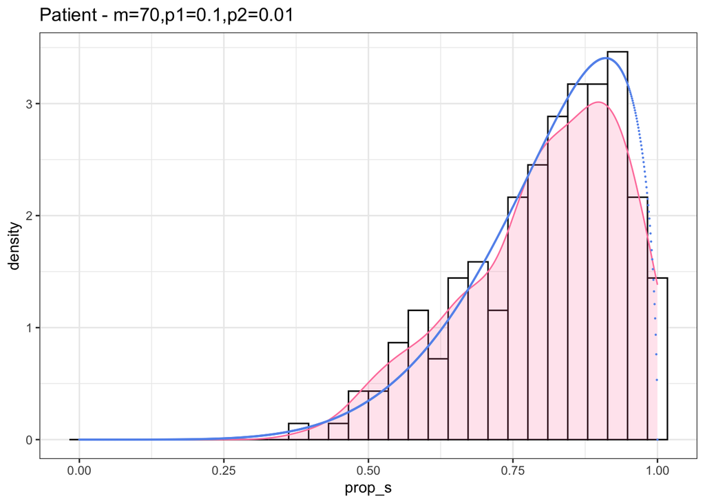

```r
# ks.test(x_1, x_2)

# Visual inspection
x <- seq(0,1,by=0.001)
fitted_val <- dbeta(x,shape1=alpha,shape2=beta)

fitted_data<-data.frame(x,fitted_val)

ggplot(num_patient_05_m70_pr2_13[800:1000,], aes(x=prop_s)) +
  geom_histogram(aes(y=..density..), colour="black", fill="white")+
  geom_density(alpha=.2, colour="palevioletred1",fill="palevioletred1")+
  geom_point(data = fitted_data, aes(x = x, y = fitted_val), colour = "cornflowerblue",size=0.1,show.legend = TRUE)+
  labs(title = "Patient - m=70,p1=0.1,p2=0.01")+
  theme_bw()
```

```r
# Patient m=70, pa=0.5, p1=0.8, p2=0.01, pr=2
data <- num_patient_05_m70_pr2_14$prop_s

exp_s<-mean(data[500:1000], na.rm = TRUE)
var_s<-var(data[500:1000],na.rm = TRUE)

alpha = exp_s*(exp_s*(1-exp_s)/var_s-1)
beta  = (1-exp_s)*(exp_s*(1-exp_s)/var_s-1)

alpha
```

```
## [1] 5.872472
```

```r
beta
```

```
## [1] 1.470176
```

```r
### Kolmogorov-Smirnov Tests
x_1 <- data
x_2 <- rbeta(n = 501, shape1 = alpha, shape2 = beta)

ks.test(x_1, "pbeta", alpha, beta)
```

```
##
##  Asymptotic one-sample Kolmogorov-Smirnov test
##
## data:  x_1
## D = 0.037749, p-value = 0.116
## alternative hypothesis: two-sided
```

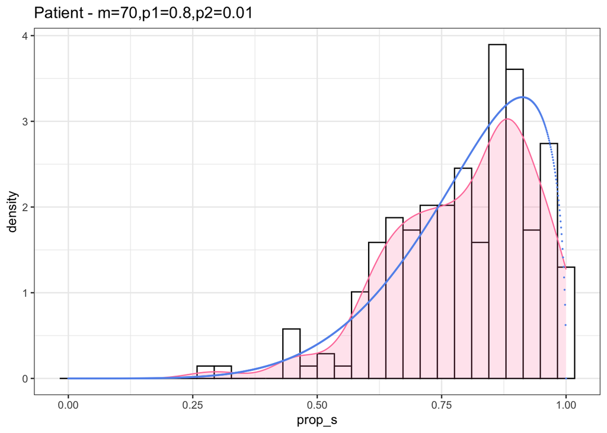

```r
# ks.test(x_1, x_2)

# Visual inspection
x <- seq(0,1,by=0.001)
fitted_val <- dbeta(x,shape1=alpha,shape2=beta)

fitted_data<-data.frame(x,fitted_val)

ggplot(num_patient_05_m70_pr2_14[800:1000,], aes(x=prop_s)) +
  geom_histogram(aes(y=..density..), colour="black", fill="white")+
  geom_density(alpha=.2, colour="palevioletred1",fill="palevioletred1")+
  geom_point(data = fitted_data, aes(x = x, y = fitted_val), colour = "cornflowerblue",size=0.1,show.legend = TRUE)+
  labs(title = "Patient - m=70,p1=0.8,p2=0.01")+
  theme_bw()
```

```r
# Patient m=100, pa=0.5, p1=0.05, p2=0.01, pr=2
data <- num_patient_05_m100_pr2_12$prop_s

exp_s<-mean(data[500:1000], na.rm = TRUE)
var_s<-var(data[500:1000],na.rm = TRUE)

alpha = exp_s*(exp_s*(1-exp_s)/var_s-1)
beta  = (1-exp_s)*(exp_s*(1-exp_s)/var_s-1)

alpha
```

```
## [1] 8.94233
```

```r
beta
```

```
## [1] 1.702057
```

```r
### Kolmogorov-Smirnov Tests
x_1 <- data
x_2 <- rbeta(n = 501, shape1 = alpha, shape2 = beta)

ks.test(x_1, "pbeta", alpha, beta)
```

```
##
##  Asymptotic one-sample Kolmogorov-Smirnov test
##
## data:  x_1
## D = 0.069272, p-value = 0.0001372
## alternative hypothesis: two-sided
```

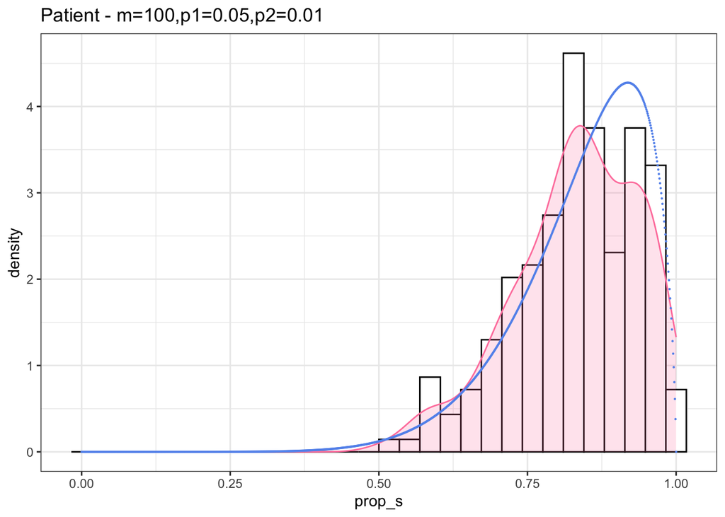

```r
# ks.test(x_1, x_2)

# Visual inspection
x <- seq(0,1,by=0.001)
fitted_val <- dbeta(x,shape1=alpha,shape2=beta)

fitted_data<-data.frame(x,fitted_val)

ggplot(num_patient_05_m100_pr2_12[800:1000,], aes(x=prop_s)) +
  geom_histogram(aes(y=..density..), colour="black", fill="white")+
  geom_density(alpha=.2, colour="palevioletred1",fill="palevioletred1")+
  geom_point(data = fitted_data, aes(x = x, y = fitted_val), colour = "cornflowerblue",size=0.1,show.legend = TRUE)+
  labs(title = "Patient - m=100,p1=0.05,p2=0.01")+
  theme_bw()
```

### Patient - group 22 (m=100, pa=0.5, p1=0.05, p2=0.01, pr=2)

```r
# Patient m=100, pa=0.5, p1=0.05, p2=0.01, pr=2
data <- num_patient_05_m100_pr2_12$prop_s

exp_s<-mean(data[500:1000], na.rm = TRUE)
var_s<-var(data[500:1000],na.rm = TRUE)

alpha = exp_s*(exp_s*(1-exp_s)/var_s-1)
beta  = (1-exp_s)*(exp_s*(1-exp_s)/var_s-1)

alpha
```

```
## [1] 8.94233
```

```r
beta
```

```
## [1] 1.702057
```

```r
### Kolmogorov-Smirnov Tests
x_1 <- data
x_2 <- rbeta(n = 501, shape1 = alpha, shape2 = beta)

ks.test(x_1, "pbeta", alpha, beta)
```

```
##
##  Asymptotic one-sample Kolmogorov-Smirnov test
##
## data:  x_1
## D = 0.069272, p-value = 0.0001372
## alternative hypothesis: two-sided
```

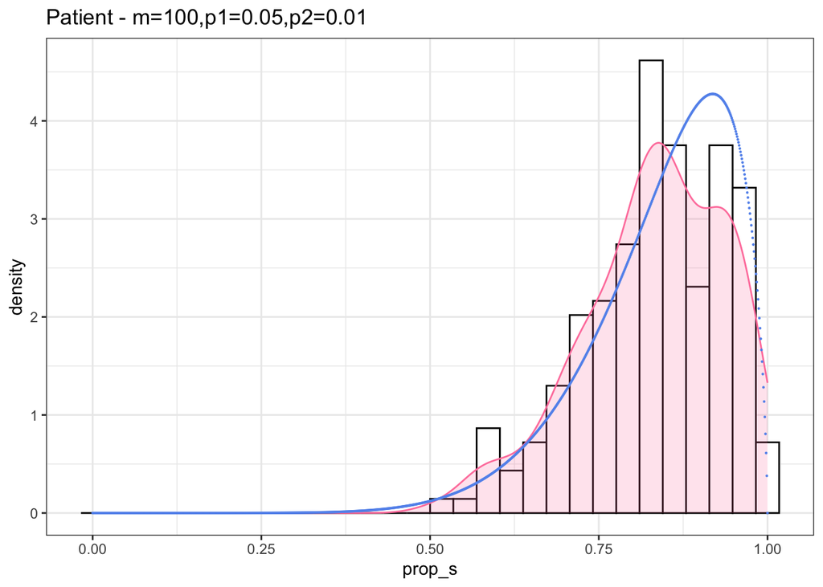

```r
# ks.test(x_1, x_2)

# Visual inspection
x <- seq(0,1,by=0.001)
fitted_val <- dbeta(x,shape1=alpha,shape2=beta)

fitted_data<-data.frame(x,fitted_val)

ggplot(num_patient_05_m100_pr2_12[800:1000,], aes(x=prop_s)) +
  geom_histogram(aes(y=..density..), colour="black", fill="white")+
  geom_density(alpha=.2, colour="palevioletred1",fill="palevioletred1")+
  geom_point(data = fitted_data, aes(x = x, y = fitted_val), colour = "cornflowerblue",size=0.1,show.legend = TRUE)+
  labs(title = "Patient - m=100,p1=0.05,p2=0.01")+
  theme_bw()
```

### ———————————————————

### Plot - group 1

```r
# Greedy m=70, pa=0.5, p1=0.05, p2=0.01, pr=2
data <-num_greedy_05_m70_pr2_12$prop_s

exp_s<-mean(data[500:1000], na.rm = TRUE)
var_s<-var(data[500:1000],na.rm = TRUE)

alpha = exp_s*(exp_s*(1-exp_s)/var_s-1)
beta  = (1-exp_s)*(exp_s*(1-exp_s)/var_s-1)

alpha
```

```
## [1] 3.801253
```

```r
beta
```

```
## [1] 1.320809
```

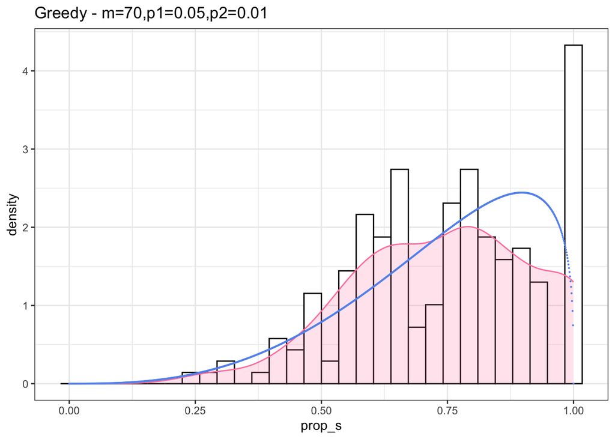

```r
# plot the beta distribution gamma(alpha, beta)

x <- seq(0,1,by=0.001)
fitted_val <- dbeta(x,shape1=alpha,shape2=beta)

fitted_data<-data.frame(x,fitted_val)

ggplot(num_greedy_05_m70_pr2_12[800:1000,], aes(x=prop_s)) +
  geom_histogram(aes(y=..density..), colour="black", fill="white")+
  geom_density(alpha=.2, colour="palevioletred1",fill="palevioletred1")+
  geom_point(data = fitted_data, aes(x = x, y = fitted_val), colour = "cornflowerblue",size=0.1,show.legend = TRUE)+
  labs(title = "Greedy - m=70,p1=0.05,p2=0.01")+
  theme_bw()
```

### Plot - group 2

```r
# Greedy m=100, pa=0.5, p1=0.1, p2=0.01, pr=2
data <-num_greedy_05_m100_pr2_13$prop_s

exp_s<-mean(data[500:1000], na.rm = TRUE)
var_s<-var(data[500:1000],na.rm = TRUE)

alpha = exp_s*(exp_s*(1-exp_s)/var_s-1)
beta  = (1-exp_s)*(exp_s*(1-exp_s)/var_s-1)

alpha
```

```
## [1] 2.57882
```

```r
beta
```

```
## [1] 1.275602
```

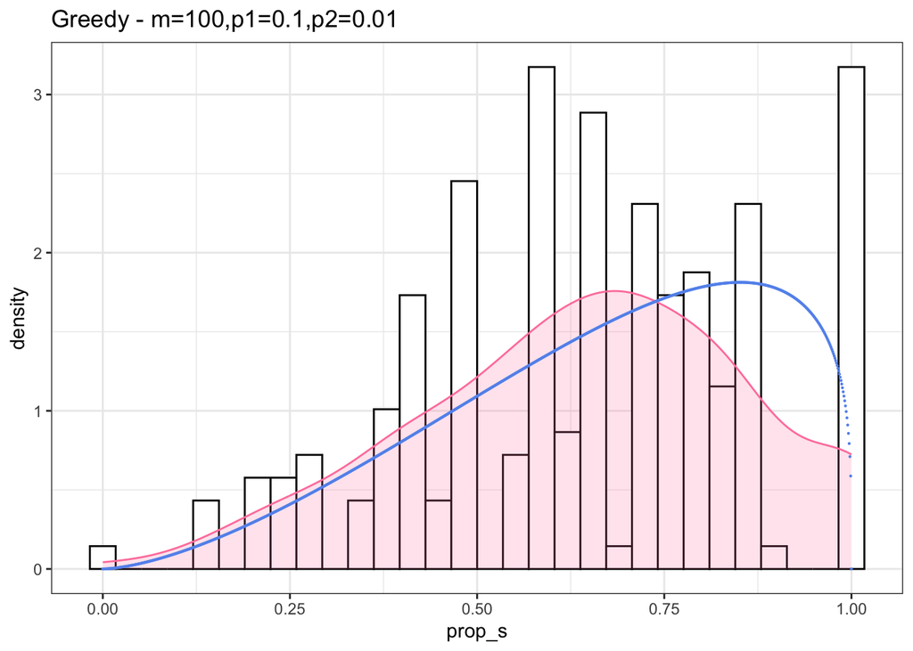

```r
# plot the beta distribution gamma(alpha, beta)

x <- seq(0,1,by=0.001)
fitted_val <- dbeta(x,shape1=alpha,shape2=beta)

fitted_data<-data.frame(x,fitted_val)


ggplot(num_greedy_05_m100_pr2_13[800:1000,], aes(x=prop_s)) +
  geom_histogram(aes(y=..density..), colour="black", fill="white")+
  geom_density(alpha=.2, colour="palevioletred1",fill="palevioletred1")+
  geom_point(data = fitted_data, aes(x = x, y = fitted_val), colour = "cornflowerblue",size=0.1,show.legend = TRUE)+
  labs(title = "Greedy - m=100,p1=0.1,p2=0.01")+
  theme_bw()
```

### Kolmogorov-Smirnov Tests

```r
# x_1 <- data
# x_2 <- rbeta(n = 501, shape1 = alpha, shape2 = beta)

ks.test(data, "pbeta", alpha, beta)
```

```
##
##  Asymptotic one-sample Kolmogorov-Smirnov test
##
## data:  data
## D = 0.14314, p-value < 2.2e-16
## alternative hypothesis: two-sided
```

## Patient Algorithm

### Plot - group 1

```r
# Patient m=70, pa=0.5, p1=0.05, p2=0.01, pr=2
data <-num_patient_05_m70_pr2_12$prop_s

exp_s <- mean(data[500:1000], na.rm = TRUE)
var_s <- var(data[500:1000], na.rm = TRUE)

alpha = exp_s*(exp_s*(1-exp_s)/var_s-1)
beta  = (1-exp_s)*(exp_s*(1-exp_s)/var_s-1)

alpha
```

```
## [1] 7.101472
```

```r
beta
```

```
## [1] 1.509657
```

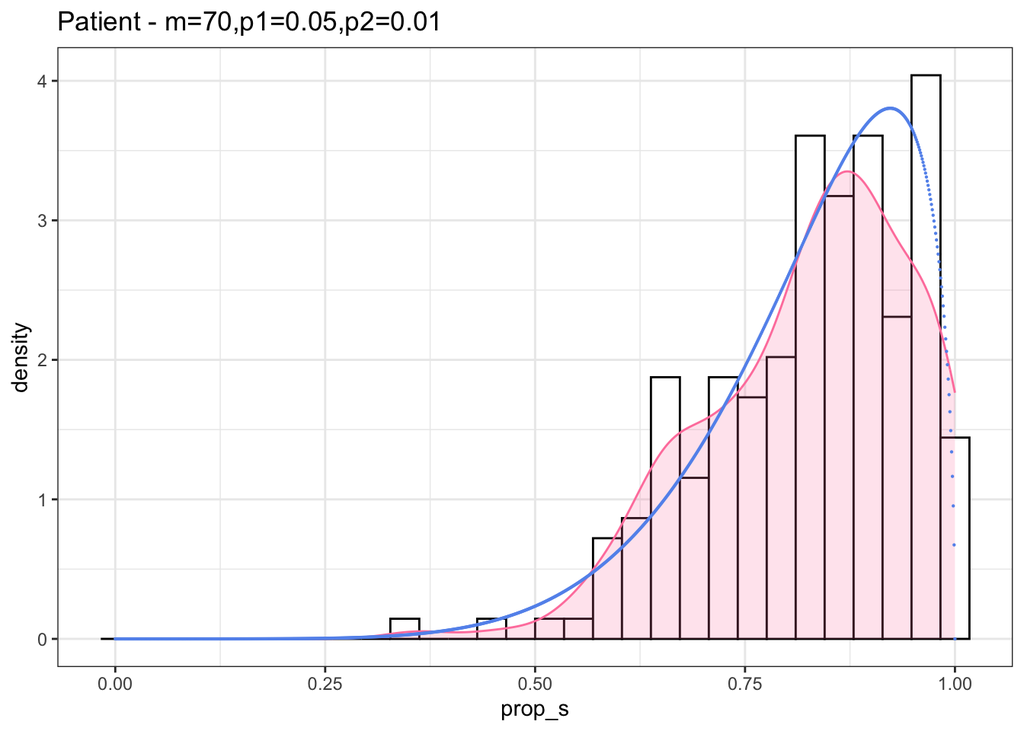

```r
# plot the beta distribution gamma(alpha, beta)

x <- seq(0,1,by=0.001)
fitted_val <- dbeta(x,shape1=alpha,shape2=beta)

fitted_data<-data.frame(x,fitted_val)

# Visual Inspection
ggplot(num_patient_05_m70_pr2_12[800:1000,], aes(x=prop_s)) +
  geom_histogram(aes(y=..density..), colour="black", fill="white")+
  geom_density(alpha=.2, colour="palevioletred1",fill="palevioletred1")+
  geom_point(data = fitted_data, aes(x = x, y = fitted_val), colour = "cornflowerblue",size=0.1,show.legend = TRUE)+
  labs(title = "Patient - m=70,p1=0.05,p2=0.01")+
  theme_bw()
```

### Kolmogorov-Smirnov Tests - group 1

```r
x_1 <- data
x_2 <- rbeta(n = 501, shape1 = alpha, shape2 = beta)

# ks.test(data, "pbeta", alpha, beta)
ks.test(x_1, x_2)
```

```
##
##  Asymptotic two-sample Kolmogorov-Smirnov test
##
## data:  x_1 and x_2
## D = 0.077161, p-value = 0.03763
## alternative hypothesis: two-sided
```

### Plot - group 2

```r
# Patient m=100, pa=0.5, p1=0.1, p2=0.01, pr=2
data <-num_patient_05_m100_pr2_13$prop_s

exp_s<-mean(data[500:1000], na.rm = TRUE)
var_s<-var(data[500:1000],na.rm = TRUE)

alpha = exp_s*(exp_s*(1-exp_s)/var_s-1)
beta  = (1-exp_s)*(exp_s*(1-exp_s)/var_s-1)

alpha
```

```
## [1] 7.665775
```

```r
beta
```

```
## [1] 1.497327
```

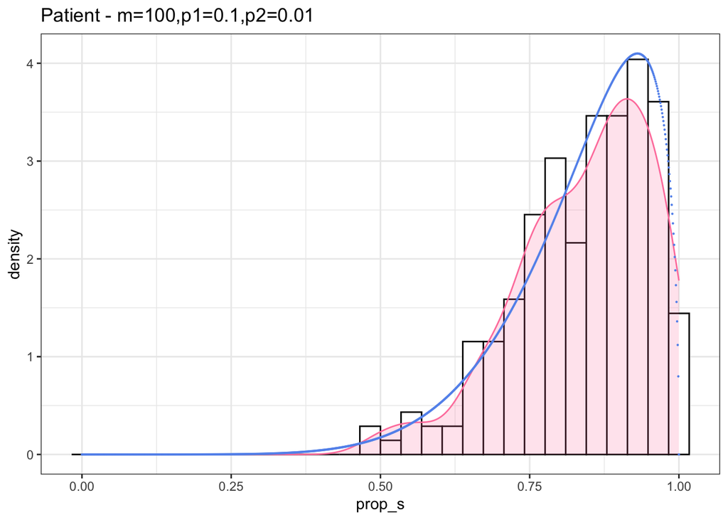

```r
# plot the beta distribution gamma(alpha, beta)

x <- seq(0,1,by=0.001)
fitted_val <- dbeta(x,shape1=alpha,shape2=beta)

fitted_data<-data.frame(x,fitted_val)

# Visual Inspection
ggplot(num_patient_05_m100_pr2_13[800:1000,], aes(x=prop_s)) +
  geom_histogram(aes(y=..density..), colour="black", fill="white")+
  geom_density(alpha=.2, colour="palevioletred1",fill="palevioletred1")+
  geom_point(data = fitted_data, aes(x = x, y = fitted_val), colour = "cornflowerblue",size=0.1,show.legend = TRUE)+
  labs(title = "Patient - m=100,p1=0.1,p2=0.01")+
  theme_bw()
```

### Kolmogorov-Smirnov Tests - group 2

```r
x_1 <- data
x_2 <- rbeta(n = 501, shape1 = alpha, shape2 = beta)

ks.test(data, "pbeta", alpha, beta)
```

```
##
##  Asymptotic one-sample Kolmogorov-Smirnov test
##
## data:  data
## D = 0.053467, p-value = 0.006614
## alternative hypothesis: two-sided
```

```r
# ks.test(x_1, x_2)
```

If we do know the true values of $\alpha$ and $\beta$, then the log-likelihood would be exactly following $\chi^2$ distribution; if we don’t know the true values of $\alpha$ and $\beta$, and we replace them with MLE, then the distribution of log-likelihood would not be $\chi^2$ distribution. So we need to examine how good the distribution is close to $\chi^2$ distribution.